# CitiBike NYC Data Exploration - Second Quarter 2020/2021

## Investigation Overview

> This investigation is about CitiBike, New York City’s bike share system with 20,000 bikes and over 1,300 stations. It will focus on trip duration and the usage of Citibike system depending on some factors.

## Dataset Overview

> The dataset contains information about trips made in CitiBike system during the second quarter of the years 2020 and 2021.

```python
# import all packages and set plots to be embedded inline
import numpy as np
import pandas as pd
import matplotlib.pyplot as plt
import seaborn as sb

%matplotlib inline

# suppress warnings from final output
import warnings
warnings.simplefilter("ignore")
```

```python
# load in the dataset into a pandas dataframe
df_f2020 = pd.read_csv('citibike_f2020.csv')
df_f2021 = pd.read_csv('citibike_f2021.csv')
```

```python
# Default values

#  set 'blue' as default color for charts.
base_color=sb.color_palette()[0]
```

```python
# functions
def format_number(value):
    '''
    Format number to thousands and millions suffix.
      Parameters:
         value (integer): number value.
      Returns:
         result (string): value with thousands/millions suffix.
    '''
    result = value
    if value >= 1000000:
        result = '{:1.1f}M'.format(value*0.000_001)
    elif value >= 1000:
        result = '{:1.0f}K'.format(value*0.001)
    return result


def pie_chart(df_col,chart_title,title_loc):
    '''
    Generate pie chart of a varaible.
      Parameters:
         df_col (pandas Series): contains column values from dataframe.
         chart_title (string): title of pie chart.
    '''
    # Get Count of each value in df_col
    value_counts = df_col.value_counts()
    labels = list(map(lambda v: v.capitalize(),list(value_counts.index)))
    # Plot the data
    plt.pie(value_counts,startangle = 90,textprops = {"fontsize":12},labels=labels,labeldistance=None,
            counterclock = False,autopct='%1.02f%%');
    # Make Pie Chart looking a circle.
    plt.axis('square')
    # Set Chart title
    plt.title(chart_title,size=14, pad=5,loc=title_loc)


def num_col_ticks(range_stop,range_step,extra_value):
    '''
    change ticks range and labels of number columns.
      Parameters:
         range_stop (number): end of range.
         range_step (number): spacing between values.
         extra_value (number): extra value.
      Returns:
         tuple: contains ticks_range and ticks_labels.
    '''
    # ticks range and labels.
    ticks_range = np.arange(start=0, stop=range_stop+extra_value, step=range_step)
    ticks_labels = list(map(lambda v: format_number(v),ticks_range))
    return (ticks_range,ticks_labels)


def count_plot(ax_indx,df_data,x_col,plot_title,title_loc,bs_color,ticks_step,extra_value):
    '''
     Generate count plot.
      Parameters:
         ax_indx(integer): plot index in figure.
         df_data (pandas dataframe): contains data.
         x_col (string): x_axis column name.
         plot_title (string): plot title.
         title_loc (string): plot title location.
    '''
    g = sb.countplot(data=df_data, x=x_col, color=bs_color, ax = ax[ax_indx]);
    # set title
    ax[ax_indx].set_title(plot_title,loc=title_loc)
    # set yticks range and labels
    ytick_rng, ytick_lbls = num_col_ticks(df_data[x_col].value_counts().sort_values().max(),ticks_step,extra_value)
    ax[ax_indx].set_yticks(ytick_rng);
    ax[ax_indx].set_yticklabels(ytick_lbls);
    ax[ax_indx].set_ylabel('');
    ax[ax_indx].set_xlabel('');

def hist(df_data,x_col,hist_title,bins_edges,xscale='',xlim=0,xticks=[],xlabels=[]):
    '''
     Generate histogram.
      Parameters:
         df_data (pandas dataframe): contains data.
         x_col (string): x_axis column name.
         hist_title (string): histogram title.
         bins_edges (list): list of histogram bins.
         xlim (integer): x_axis limit.
         xticks (list): xticks range.
         xlabels (list): xticks labels.
    '''
    plt.hist(data = df_data, x = x_col, bins = bins_edges);
    if xlim != 0 :
        plt.xlim(0, 500);
    if xscale != '':
        plt.xscale(xscale);
    if len(xticks) and len(xlabels) > 0:
        plt.xticks(xticks,xlabels);
    plt.title(hist_title)

def box_plot(df_data,x,y,chart_title,bs_color=None,ylim=100,xlabel='',x_order=None,ylabel='',x_rot_deg=0):
    '''
    Generate box plot.
      Parameters:
         df_data (pandas dataframe): contains data.
         x (string): x_axis column name.
         y (string): y_axis column name.
         chart_title (string): chart title.
         xlabel (string): x_axis label.
         ylabel (string): y_axis label.
         ylim (integer): y_axis limit.
         base_color (string): plot base color.
         x_rot_deg (integer): axes label.
    '''
    if bs_color is None:
        g = sb.boxplot(data=df_data, x=x, y=y,order=x_order);
    else:
        g = sb.boxplot(data=df_data, x=x, y=y, color=bs_color,order=x_order);
    plt.ylim(0, ylim);
    plt.xlabel(xlabel)
    plt.ylabel(ylabel)
    plt.xticks(rotation=x_rot_deg)
    plt.title(chart_title)
```

## Citibike Usage by Gender Q2/2020

> In the second quarter of 2020, 56% of CitiBike users were male. And 30% of its users were female.

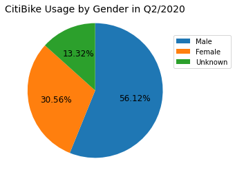

```python
# Plot user gender in 2020 using pie chart.
pie_chart(df_f2020['gender'],'CitiBike Usage by Gender in Q2/2020','center')
plt.legend(bbox_to_anchor=(1.00,0.891), loc="upper left");
```

## Usage (%) of bike types Q2/2021

> Docked bike is the preferred bike for CitiBike users in the second quarter of 2021. Around 86% CitiBike users prefer Docked bike than other types. Electric Bike has 0% that means had been used few times over 3 months, maybe because of its price per minute compared to others.

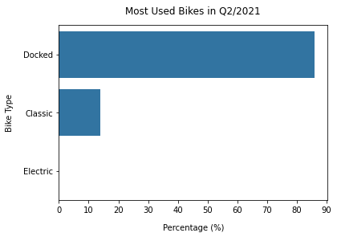

```python
# Plot a bar chart having the percentages, instead of the actual count.

# Count the frequency of unique values in the `bike_type` column in 2021.
type_counts = df_f2021['bike_type'].value_counts()

# Get the unique values of the `bike_type` column, in the decreasing order of the frequency.
type_order = type_counts.index

# Compute the length of the longest bar in terms of the proportion
max_prop = type_counts[0] / df_f2021.shape[0]

# Use numpy.arange() function to produce a set of evenly spaced proportioned values
#   between 0 and max_prop, with a step size 10%
tick_props = np.arange(0, max_prop+0.1, 0.1)

# Pick each element `v` from the `tick_props`, and convert it into a formatted string.
tick_names = ['{:0.0f}'.format(v*100) for v in tick_props]

#Plot the bar chart
sb.countplot(data=df_f2021, y='bike_type', color=base_color, order=type_order);

# Set xticks, labels and title of the chart
plt.xticks(tick_props * df_f2021.shape[0], tick_names)
plt.xlabel('Percentage (%)',labelpad=12);
plt.ylabel('Bike Type',labelpad=12);
plt.title('Most Used Bikes in Q2/2021',pad=15);
```

## Number of Trips per year

> There are 563 new stations used in 2021 that means convering more areas of New York City. The number of trips in 2021 has almost doubled.

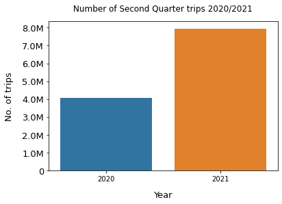

```python
# Return the Series having count of trips from years dataframes.
yrs_trip_count = pd.Series([df_f2020.shape[0],df_f2021.shape[0]]);
yaxis_range, yaxis_labels = num_col_ticks(max(yrs_trip_count),1000000,500000);

# Plot counts using bar chart
sb.barplot(data = yrs_trip_count, x = ['2020','2021'], y = yrs_trip_count);

# Set yticks range and labels
plt.yticks(yaxis_range,yaxis_labels, fontsize=13);
# Set chart title and x,y labels
plt.title('Number of Second Quarter trips 2020/2021',pad = 15);
plt.xlabel('Year',labelpad = 12,size= 13);
plt.ylabel('No. of trips',labelpad = 12,size= 13);
```

## Citibike Usage by User

> Around 70% of the total trips were made by Members in 2020 and 2021. There is a tiny difference between percentages of 2021 and 2020.

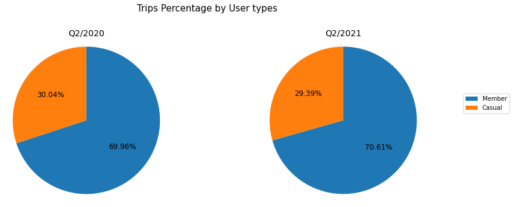

```python
# Plot two pie charts side-by-side for years 2020 and 2021.
# Set a larger figure size for subplots
fig = plt.figure(figsize = [14, 5])

# pie chart on left for year 2020.
plt.subplot(1, 2, 1)
pie_chart(df_f2020['member_casual'],'Q2/2020','center')

# pie chart on right for year 2021.
plt.subplot(1, 2, 2)
pie_chart(df_f2021['member_casual'],'Q2/2021','center')

# Set Main tile, legend and x,y labels of figure
leg_lines,leg_labels = plt.gca().get_legend_handles_labels()
fig.legend(leg_lines, leg_labels, loc='center right')
fig.suptitle('Trips Percentage by User types',size= 15,y=1.04);
```

## CitiBike Usage Rush Hours

> CitiBike usage gradually increases from 8 AM to 6 PM. That's aligned with normal working hours in New York City.

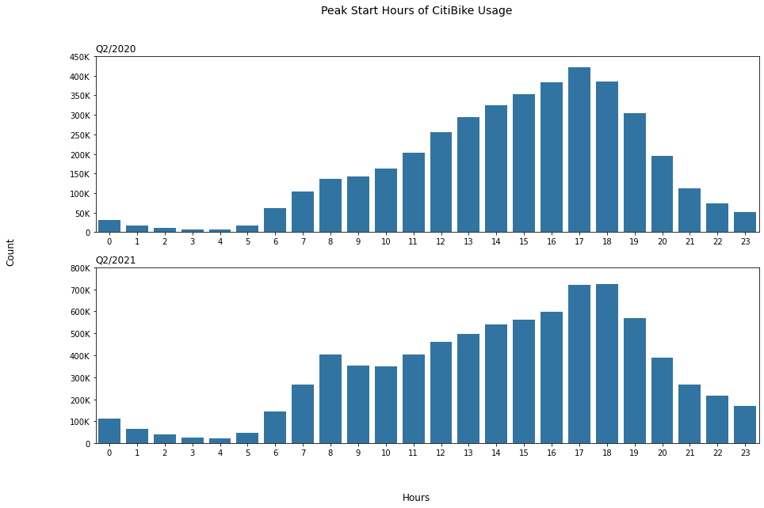

```python
# Plot two bar charts for 2020 and 2021.
#  set a larger figure size for subplots
fig, ax = plt.subplots(nrows=2, figsize = [15,9])

# year 2020
count_plot(0,df_f2020,'start_hour','Q2/2020','left',base_color,50000,50000)

# year 2021
count_plot(1,df_f2021,'start_hour','Q2/2021','left',base_color,100000,100000)

# Set Main tile and x,y labels of figure
fig.supylabel('Count')
fig.supxlabel('Hours')
fig.suptitle('Peak Start Hours of CitiBike Usage',size= 14);
```

## Average of Trip Duration

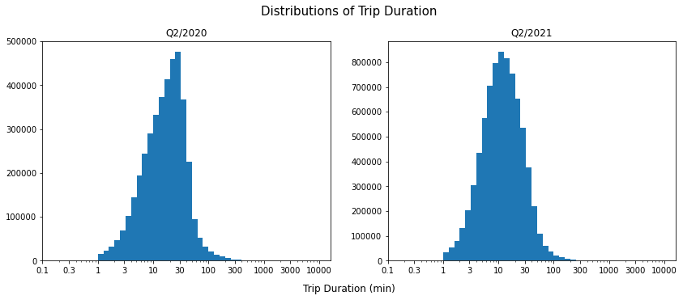

```python
# A a logarithmic transformation to 'Trip Duration' histograms

#  set xticks labels
ticks = [0.1,0.3,1,3,10,30,100,300,1000,3000,10000]
labels = ['{}'.format(val) for val in ticks]
bins_edges = 10**np.arange(0,4.0+0.1,0.1)

# Set a larger figure size for subplots
fig=plt.figure(figsize = [14, 5])


# year 2020

#  left hist
plt.subplot(1, 2, 1)
hist(df_f2020,'duration_min','Q2/2020',bins_edges,xscale='log',xticks=ticks,xlabels=labels)

# year 2021
#  right hist
plt.subplot(1, 2, 2)
hist(df_f2021,'duration_min','Q2/2021',bins_edges,xscale='log',xticks=ticks,xlabels=labels)

# Set Main tile and x labels of figure
fig.supxlabel('Trip Duration (min)')
fig.suptitle('Distributions of Trip Duration',size= 15,y=1.001);
```

## Number of Trips per month

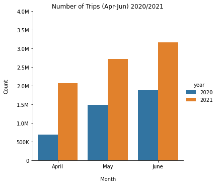

```python
# Get trips per month from 2020 and 2021 dataframes.
#  dataframe of counts per month for years.
df_yrs_month = pd.DataFrame(columns=['year','month_count','start_month']);
#     generate
for yr_dt in [['2020',df_f2020],['2021',df_f2021]]:
    df_yr = pd.DataFrame()
    df_yr['month_count'] =  yr_dt[1]['start_month'].value_counts().sort_values().to_list()
    df_yr['start_month'] =  yr_dt[1]['start_month'].value_counts().sort_values().index
    df_yr['year'] = yr_dt[0]
    df_yrs_month = df_yrs_month.append(df_yr, ignore_index = True)

# Plot dataframe of counts per month in one chart.
g = sb.catplot(x='start_month',y='month_count', hue='year', kind='bar', data=df_yrs_month);
#   set yticks range and labels
ytick_rng_21, ytick_lbls_21 = num_col_ticks(df_yrs_month['month_count'].max(),500000,1000000);
g.set(yticks=ytick_rng_21,yticklabels=ytick_lbls_21);
#   set chart title
g.ax.set_title("Number of Trips (Apr-Jun) 2020/2021");
#   set axes labels
g.ax.set_xlabel("Month",labelpad=15);
g.ax.set_ylabel("Count",labelpad=15);
```

## Average of Trip Duration by User Type

> The average of trip duration for Casual users is higher than Member users. Maybe it is due to mostly the user who has a membership is a NYC local. But casual user represents visitors or tourists to NYC meaning longer distances to discover NYC.

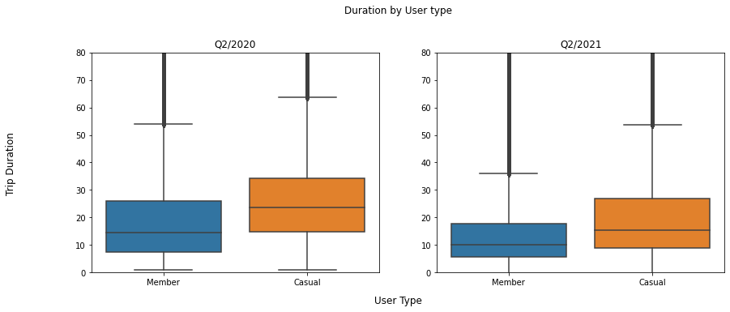

```python
# Plot two box plots for years 2020 and 2021.
# Set a larger figure size for subplots
fig=plt.figure(figsize = [14, 5])

# left plot for year 2020.
plt.subplot(1, 2, 1)
box_plot(df_f2020,'member_casual','duration_min','Q2/2020',ylim=80)

# right plot for year 2021.
plt.subplot(1, 2, 2)
box_plot(df_f2021,'member_casual','duration_min','Q2/2021',ylim=80)


# Set Main tile and x,y labels of figure
fig.supylabel('Trip Duration')
fig.supxlabel('User Type')
fig.suptitle('Duration by User type',y=1.04);
```

## Trip Duration by Gender and User Type Q2/2020

> The average of trip duration for member females is higher than the average of trip duration for other members (male and unknown). The trip duration average of casual users is approximately equal for all genders.

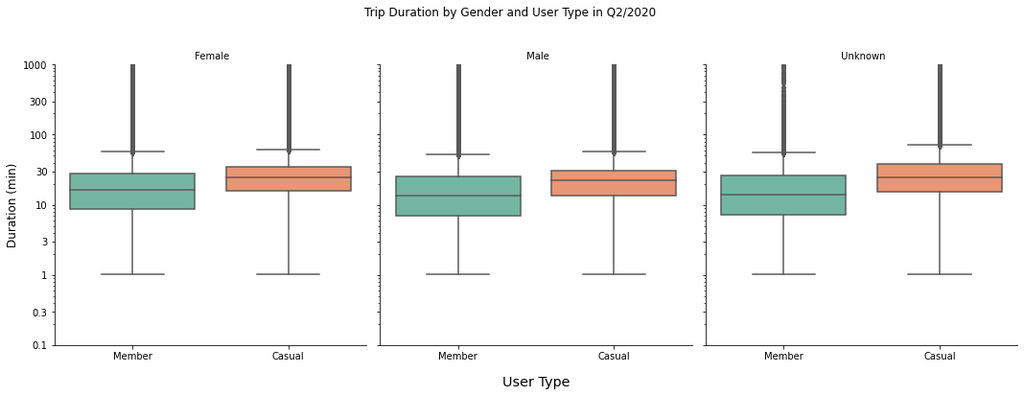

```python
# Plot the relationship between gender, user type and trip duration using FacetGrid of boxplots.
g = sb.FacetGrid(data = df_f2020, col = 'gender', height = 5)
g.map(sb.boxplot, 'member_casual', 'duration_min', palette="Set2",order=df_f2020.member_casual.value_counts().index)

# Generate y_axis ticks and labels.
y_ticks = [0.1,0.3,1,3,10,30,100,300,1000]
y_labels = ['{}'.format(val) for val in y_ticks]


# Remove '=' from box_plot title. Since title of boxplot in facetgrid includes '=', ex."gender = female".
for ax in g.axes.flat:
    if ax.get_title():
        ax.set_title(ax.get_title().split('=')[1],fontsize='medium')


# apply logarithmic transformation to 'Trip Duration' to make chart interpretable
plt.yscale('log')

# Set limit to y_axis
plt.ylim(0.1,1000)

#  set y_axis title, ticks and labels.
plt.yticks(y_ticks, y_labels);
g.set_axis_labels(x_var="", y_var="Duration (min)",fontsize='large');

# Set x_axis label
g.axes[0,1].set_xlabel('User Type',labelpad=15,fontsize='x-large');

# Set Chart Title
plt.suptitle("Trip Duration by Gender and User Type in Q2/2020", y=1.10);
```

## Average of Trip Duration by User and Bike Types Q2/2021

> The average of trip duration is longer when using Docked bike than using Classic bike for Casual and Member users.

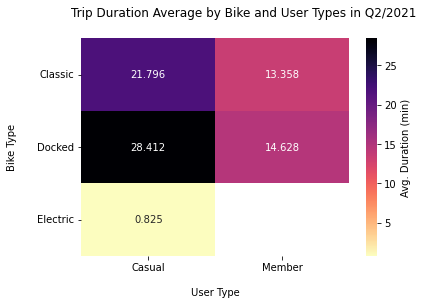

```python
# Plot the relationship between bike type, user type and trip duration using heatmap.

#  first, group trips by user type and bike type then get average of trip duration of these trips.
cat_means = df_f2021.groupby(['member_casual', 'bike_type']).mean()['duration_min']
cat_means = cat_means.reset_index(name = 'Avg. Duration (min)')

#  use pivot_table function to spread the data from long form to tidy form to generate heatmap.
cat_means = cat_means.pivot(index = 'bike_type', columns = 'member_casual',values = 'Avg. Duration (min)')

#  generate the heatmap
sb.heatmap(cat_means, annot = True, fmt = '.3f',cbar_kws = {'label' : 'Avg. Duration (min)'}, cmap = 'magma_r');

# Set x,y axes labels.
plt.yticks(rotation=0)
plt.ylabel('Bike Type',labelpad=20);
plt.xlabel('User Type',labelpad=15);
plt.suptitle("Trip Duration Average by Bike and User Types in Q2/2021", y=0.99);
```